# Collocated (CCK) vs. Ordinary Kriging (OK)

Appunti di geostatistica con R

Autore

Massimo Bressan

data ultima modifica

2025-11-21

# Premessa

Questo breve documento raccoglie alcune osservazioni sulla tecnica di **“collocated cokriging”** (da non confondere con “full cokriging”) che traggono spunto dalle lezioni del corso: “ANALISI GEOSTATISTICA DEI DATI AMBIENTALI – Livello base”, tenuto dal Prof. Pirotti (UniPD) presso ARPAV nell’ottobre-novembre 2025 (per un totale di 12 h complessive).

Si tratta di una ri-elaborazione personale del codice di esempio riportato a pag 213 del testo:

- R.S. Bivand, E.J. Pebesma, V. Gómez-Rubio, 2008. Applied Spatial Data Analysis with R, Springer, [link free pdf download](https://gis.humboldt.edu/OLM/r/Spatial%20Analysis%20With%20R.pdf)

Di seguito sono proposte ed illustrate alcune considerazioni preliminari da espandere come eventuale esercizio di approfondimento individuale.

# Setup dataset “meuse”

Passaggi chiave:

- caricamento datasets in formato dataframe puntuale (“matrice sparsa”) e grid (“matrice regolare densa”);
- trasformazione dataframe (plain vanilla) in corrispondenti oggetti “geografici” (cioè dotati di un riferimento univoco ad un CRS predefinito) del tipo: “SpatialPontsDataFrame”, “SpatialPixelDataFrame” e “Spatialpoints”, tipici della libreria “sp” (richiamata indirettamente da “gstat”).

```r
# libraries ----------------------------------------------------------

library(sp)
#library(mapview)

if(!require(mapview)){
  install.packages("mapview")
  library(mapview)
  }

library(gstat)


# load dataset meuse and georeference  ------------------------------------

# dataset meuse points
data(meuse)
# set coordinates
coordinates(meuse) <- ~x+y
# set crs for mapping
proj4string(meuse) <- CRS("epsg:28992")

# this is not raising the warning
# https://inbo.github.io/tutorials/tutorials/spatial_crs_coding/
#crs <- CRS(SRS_string = "EPSG:28992")
#slot(meuse, "proj4string") <- crs



# let's do the same with the grid
data(meuse.grid)
coordinates(meuse.grid) <- ~x+y
gridded(meuse.grid)<-TRUE
proj4string(meuse.grid) <- CRS("epsg:28992")

# later to be used as overlay points in spplot
xy <- SpatialPoints(coordinates(meuse))
```

Per una verifica dell’ubicazione geografica del dataset “meuse” e della densità di punti di campionamento. *Attenzione: si tratta di una condizione pressoché “ideale” ed unica, non aspettiamoci che i dataset “reali” con cui abbiamo normalmente a che fare siano così “generosi di punti e così facilmente addomesticabili”.*

```r
# plot just to know where is meuse
mapview(meuse)
```

[interactive chart not shown]

# Il modello di variogramma

Non si entra qui nella discussione delle scelte relative alla parametrizzazione del variogramma che vengono date per consolidate nonostante questa parte fondamentale sia essenziale (e non derogabile) nel processo di kriging.

Per semplicità espositiva, e quindi ai soli fini “didattici” di questo esempio, tutto il preliminare lavoro di analisie parametrizzazione fine del variogramma viene dato per acquisito.

Autocorrelazione spaziale del logaritmo delle concentrazioni di Zinco (Zn).

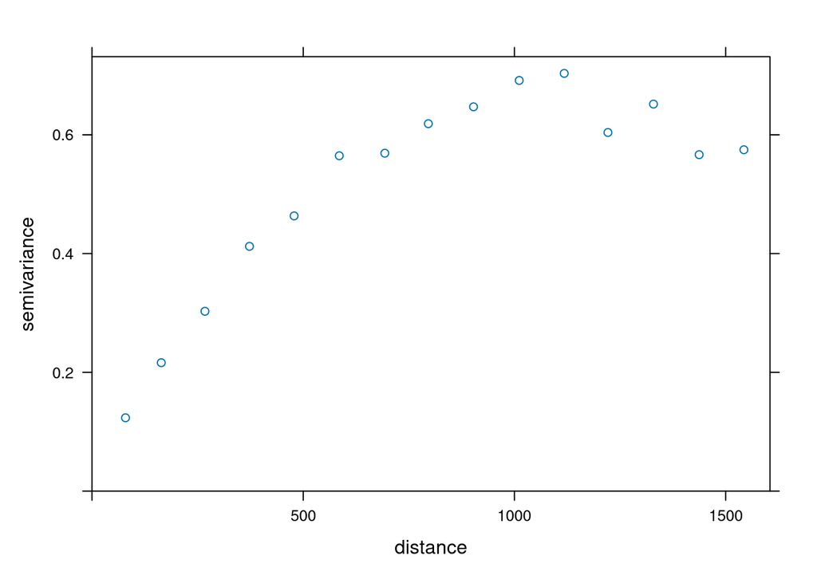

```r
# steps:
# 1. choose a suitable model
# 2. choose suitable initial values for partial sill(s), range(s), and possibly nugget
# 3. fit the model (using one of the fitting criteria)

v <- variogram(log(zinc) ~ 1, meuse)
plot(v)
```

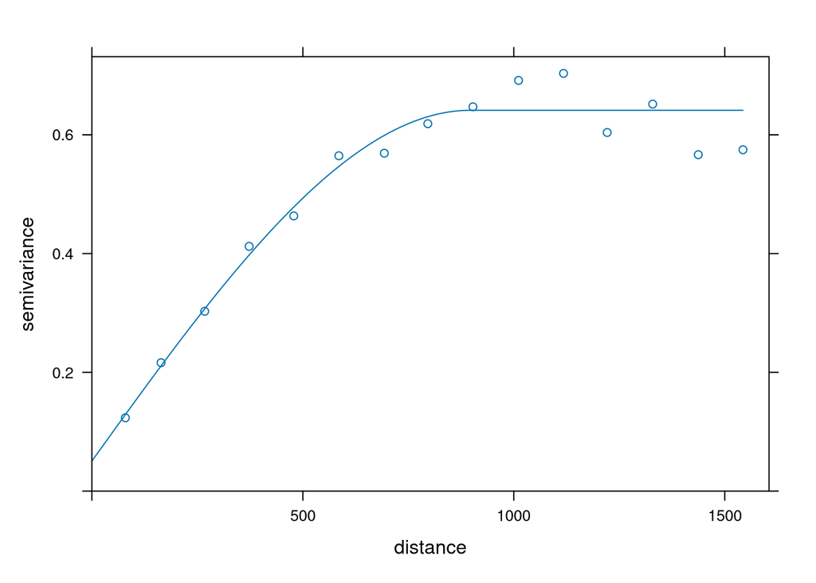

```r
v.fit <- fit.variogram(v, vgm(1, "Sph", 800, 1))
plot(v, v.fit)
```

```r
# a final check that everything went fine (i.e. it is "invertible" in term of matrix calculations)
if (attr(v.fit, "singular")) stop("no, a singular fit, check again!") else("yes, it's fine!")
```

```
[1] "yes, it's fine!"
```

# Collocated cokriging (CCK)

Chiariamo che cosa si intende con “collocated cokring”, a che cosa serve e perchè è stato “inventato”. Si tratta di una delle tante varianti della tecnica generale di kriging (interpolazione spaziale di tipo statistico - non deterministico!), in particolare del “cokriging”.

- *Cokriging (CK)* è una tecnica statistica multivariata che utilizza l’autocorrelazione spaziale di una variabile primaria `log(zinco)` e la *cross-correlazione* con una variabile secondaria (`dist` distanza dal fiume Meuse) per migliorare la predizione.
- *Collocated Cokriging (CCK)* è una forma semplificata di Cokriging, principalmente utile quando il valore della variabile secondaria è noto ovunque sul dominio di calcolo (cioè sull’intero reticolo di predizione `meuse.grid`) mentre la variabile primaria è campionata solo in alcuni punti del dominio di calcolo (`meuse`).

*Questo tipo di “semplificazione” assume che il valore di una variabile secondaria sia importante esclusivamente corrispondenza dei punti di predizione, evitando in questo modo la necessità di analizzare il cross-variogramma completo rispetto a tutte le possibili distanze*.

CCK presume che il valore della variabile secondaria sia noto in ogni punto della griglia di calcolo cioè, in altri termini, ipotizza che la variabile secondaria collocata in una posizione vicina riesca a *“schermare”* l’influenza dei dati secondari più lontani, il che semplifica drasticamente il sistema di kriging. In questo modo, si ottengono i benefici del Cokriging (riduzione della varianza) senza la complessità di dover modellare l’intero cross-variogramma per tutte le possibili distanze (lag) all’interno dell’area di studio.

- Assunzione di screening
  - il Cokriging Collocato (CCK) si basa sull’idea che, nel punto di previsione, la conoscenza esatta del valore della variabile secondaria (dist, distanza dal fiume) è così potente da rendere ‘irrilevante’ la necessità di conoscere tutti gli altri valori della variabile secondaria campionati nei punti vicini (in altri termini rifiuta o meglio rilassa uno dei concetti centrali del kriging - vicinaggio, neighborhorood - in favore dell’utilizzo di una variabile secondaria che si ritiene essere più rappresentativa e significativa). In pratica, il valore della variabile secondaria proprio in ogni specifico punto della griglia di calcolo funge da “schermo” di altre varaibili esplicative e condensa tutta l’informazione geografica e statistica utile per la stima (attenzione: è un’assunzione molto forte - nega molto - e non facilmente verificabile nei dataset “reali”).
- Semplificazione del sistema
  - kriging ordinario: usa solo i dati della variabile primaria `log(zinco)`.
  - Cokriging Completo: deve usare tutti i punti della variabile primaria e tutti i punti della variabile secondaria `dist` nel vicinato, risultando in una matrice complessa e grande da risolvere.
  - Cokriging Collocato (CCK): usa tutti i punti della variabile primaria ma aggiunge soltanto il valore della variabile secondaria che si trova esattamente nel punto da predire (ignora vicinaggio). Questo ‘espediente’ mantiene la dimensione della matrice (varianza/covarianza) molto più contenuta e riduce il tempo di calcolo.
- Beneficio geostatistico/computazionale
  - Il Cokriging è prezioso perché, aggiungendo un’informazione correlata e più densa, riduce l’incertezza (la varianza di stima).
  - Il CCK ottiene questa stessa riduzione della varianza, ma senza dover affrontare il passo più difficile del Cokriging completo (full cockriging) e cioè la modellazione del cross-variogramma, ovvero la relazione spaziale tra varaibile primaria e secondaria a tutte le possibili distanze (definite nel variogramma!).

Codice di esempio riportato a pag. 213 del testo di Bivand et al.

```r
# let's consider log(zinc) as primary and dist as secondary variable
g.cc <- gstat(NULL, "log.zinc", log(zinc) ~ 1, meuse,  model = v.fit)

# this is quite misleading by calling it distn because it's no longer a distance but somethingelse completely different...
meuse.grid$distn <- meuse.grid$dist - mean(meuse.grid$dist) +  mean(log(meuse$zinc))

vd.fit <- v.fit
vov <- var(meuse.grid$distn)/var(log(meuse$zinc))

vd.fit$psill <- v.fit$psill * vov

g.cc <- gstat(g.cc,
              "distn",
              distn ~ 1,
              meuse.grid,
              nmax = 1,
              model = vd.fit,
              merge = c("log.zinc", "distn")
              )

vx.fit <- v.fit

vx.fit$psill <- sqrt(v.fit$psill * vd.fit$psill) * cor(meuse$dist, log(meuse$zinc))

g.cc <- gstat(g.cc, c("log.zinc", "distn"), model = vx.fit)

cck.pred <- predict(g.cc, meuse.grid)
```

```
Intrinsic Correlation found. Good.
[using ordinary cokriging]
```

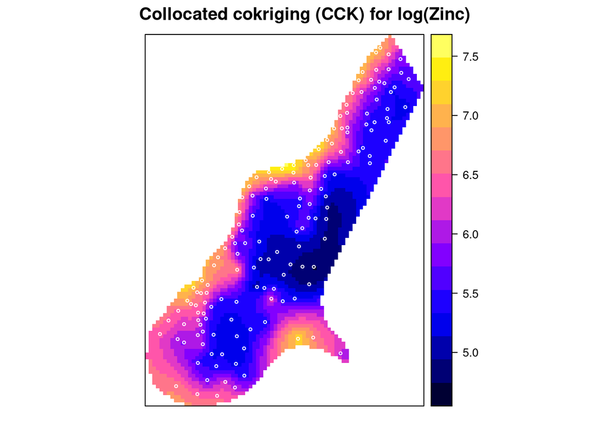

```r
names(cck.pred)[1] <- "CCK_Prediction"

spplot(cck.pred["CCK_Prediction"],
       sp.layout = list("sp.points", xy, pch=1, col="white", cex=0.4),
       main = "Collocated cokriging (CCK) for log(Zinc)")
```

# Ordinary kriging (OK)

OK assume che la media della variabile primaria (`log(Zn)`) sia costante ma non nota su tutto il dominio di predizione (diversamente da simple kriging). OK utilizza solo le informazioni spaziali che derivano dal variogramma della variabile primaria per determinare i pesi della regressione di kriging.

```r
# 1. Variogram (same as before)
v.ok <- variogram(log(zinc) ~ 1, meuse)
v.ok.fit <- fit.variogram(v.ok, vgm(1, "Sph", 800, 1))

# 2. Setup gstat object
# The formula log(zinc) ~ 1 specifies ordinary kriging.
g.ok <- gstat(NULL, "log.zinc", log(zinc) ~ 1, meuse, model = v.ok.fit)

# 3. Predict
ok.pred <- predict(g.ok, meuse.grid)
```

```
[using ordinary kriging]
```

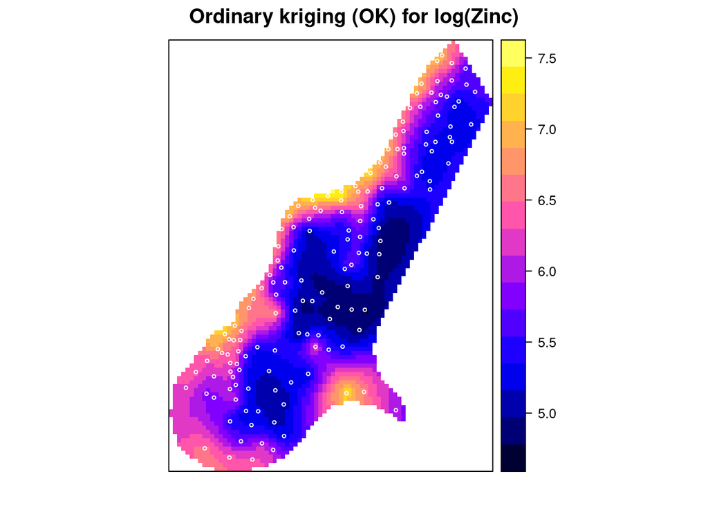

```r
names(ok.pred)[1] <- "OK_Prediction"

spplot(ok.pred["OK_Prediction"],
       sp.layout = list("sp.points", xy, pch=1, col="white", cex=0.4),
       main = "Ordinary kriging (OK) for log(Zinc)")
```

# Predict OK vs. CCK

Di seguito un confronto tra i risultati di predizione effettuati con kriging ordinario (OK) vs. cokriging collocato (CCK).

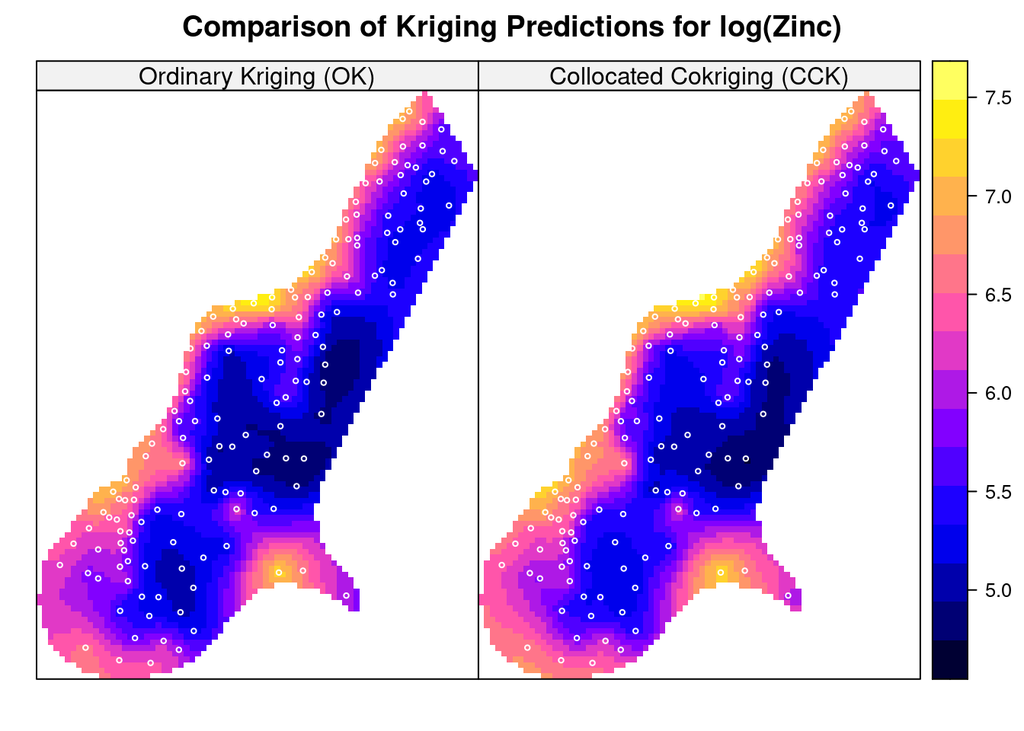

```r
delta_pred_ok_cck <- ok.pred@data$OK_Prediction - cck.pred@data$CCK_Prediction

meuse.grid$delta_pred_ok_cck <- delta_pred_ok_cck
meuse.grid$pred_ok <- ok.pred$OK_Prediction
meuse.grid$pred_cck <- cck.pred$CCK_Prediction

ok_cck_preds <- cbind(meuse.grid["pred_ok"],
                   meuse.grid["pred_cck"])

spplot(ok_cck_preds,
       names.attr = c("Ordinary Kriging (OK)",
                      "Collocated Cokriging (CCK)"),
       #col.regions = terrain.colors(100),
       layout = c(2, 1),
       sp.layout = list("sp.points", xy, pch=1, col="white", cex=0.4),
       main = "Comparison of Kriging Predictions for log(Zinc)")
```

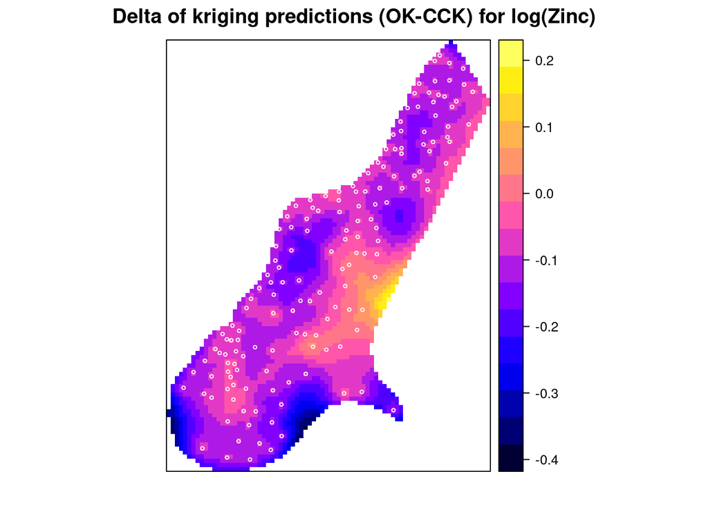

```r
spplot(meuse.grid["delta_pred_ok_cck"],
       sp.layout = list("sp.points", xy, pch=1, col="white", cex=0.4),
       main = "Delta of kriging predictions (OK-CCK) for log(Zinc)")
```

Dal confronto tra le mappe di predizione si tende ad osservare quanto segue (anche se non è chiarissimo il segnale perchè le differenze sono davvero minime - cfr. delta map):

- OK: evidenzia valori più “lisciati” (smoothed) che riflettono solo la dipendenza dalla distanza definita dal variogramma `log(zinco)`;
- CCK: evidenzia un gradiente più marcato e definito delle elevate concentrazioni di zinco in prossimità del fiume (a bassi valori di distanza dal fiume); evidenzia, in altri termini, come la predizione venga forzata a seguire in modo più chiaro il trend spaziale “catturato” dalla variabile secondaria, altamente correlata (distn): se la correlazione tra zinco e la distanza risulta elevata (in magnitudo), il CCK determina una significativa alterazione della superficie di kriging.

Sintesi tabellare confronto OK vs. CCK

[output not shown]

# Considerazioni finali e possibili criticità rilevate

La seguente linea di codice nell’esempio di collocated cokriging (CCK) e qui di seguito riportata:

`meuse.grid$distn <- meuse.grid$dist - mean(meuse.grid$dist) + mean(log(meuse$zinc))`

assume implicitamente una serie di considerazioni molto importanti che se non vengono valutate con molta attenzione possono determinare possibili errori e/o significativi fraintendimenti.

*Si tratta di un espediente di calcolo utilizzato spesso negli esempi di collocated cokriging (CCK) che ha però l’effetto di mescolare variabili che nativamente hanno magnitudo ed unità di misura differenti.*

Si tratta quindi di un processo di “normalizzazione” da considerare **solo ed esclusivamente ai fini didattici dell’esempio sopra riportato e non come “procedura operativa” di calcolo** da utilizzare “semplicemente” in tutte le stime con collocated cokriging (CCK).

Consiserato che:

- `meuse.grid$dist`: è la distanza dal fiume (in metri)
- `log(meuse$zinc)`: è la trasformazione logaritmica delle concentrazioni di zinco (in mg/kg)

analizziamo passo-passo la precedente espressione:

- `meuse.grid$dist - mean(meuse.grid$dist)`: centra la variabile distanza `dist` sul valore zero (sottrae la media);
- `+ mean(log(meuse$zinc))`: somma il valore medio del log delle concentrazioni di zinco e quindi sposta (shifta) il valore precedentemente centrato della variabile `dist` in modo che assuma approssimativamente lo stesso valore medio della variabile `log(zinc)` (a meno del “rumore di fondo” originariamente presente nella variabile `dist`)

Questo “trucchetto” crea una nuova variabile chiamata in modo del tutto fuorviante `distn` (distanza normalizzata) che risulta approssimativamente centrata sullo stesso valore medio di `log(zinc)`.

*Ma perchè mai è stata fatta questa operazione (del tutto arbitraria) che crea non poca confusione (almeno per me)?*

Nel collocated cokriging (CCK), l’idea centrale è utilizzare una variabile secondaria il cui valore è noto in tutti i punti della griglia di calcolo e che risulta significativamente correlata con la variabile primaria `log(zinc)`.

La formulazione del CCK richiede che entrambe le variabili abbiano una media simile (ed a volte varianza simile) altrimenti il sistema può risultare numericamente instabile e/o biased.

*Bisogna quindi intendere questo aggiustamento come una centratura “ad hoc” in modo tale che la variabile secondaria risulti approssimativamente sulla stessa scala di misura della variabile primaria `log(zin)` e sia ad essa significativamente correlata.* Non viene effettuato un cambiamento del pattern spaziale della variabile `dist` ma bensì solo un `offset` del suo valore medio.

*Ma allora perchè questa operazione risulta potenzialmente “problematica”?*

Le variabili `dist` and `log(zinc)` hanno una magnitudo una dispersione molto differente:

| Variable | Range | Unità | Natura della variabile |
| --- | --- | --- | --- |
| `log(zinc)` | ~ 4–8 | mg/kg | misura ambientale |
| `dist` | ~ 0–1000 | meters | prossimità spaziale |

Tramite l’operazione di sottrazione ed addizione dei rispettivi valori medi le due variabili in gioco non sono state rese effettivamente comparabili perchè è stato effettuato solo uno spostamento (shift) della variabile secondaria (ma varianza ed unità di misura rimangono completamente differenti).

Nel (full) cokriging (CK) questa discrepanza può produrre un matrice del variogramma di tipo singolare (non invertibile).

Forse l’approccio più robusto dal punto di vista statistico potrebbe essere quello di standardizzare (scale) le variabili in modo tale che entrambe risultino con media zero e varianza 1 (per definizione di `scale()`).

```r
meuse$log_zinc <- scale(log(meuse$zinc))
meuse$distn <- scale(meuse$dist)
meuse.grid$distn <- scale(meuse.grid$dist)
```

|  | Significato | Problema rilevato | Possibile soluzione |
| --- | --- | --- | --- |
| `dist - mean(dist)` | centra la variabile `dist` (toglie media) | — | — |
| `+ mean(log(zinc))` | sposta la media per farla coincidere con `log(zinc)` | Ri-scalamento arbitrario tra unità di misura differenti | Scalare entrambe le variabili |
| Obiettivo principale | Allinea la variabile secondaria alla primaria | obiettivo raggiunto ma in modo non rigoroso e trasparente | Utilizzo di `scale()` per corretta normalizzazione |
| Effetto | Cambia solo la media non la dispersione | Varianza differente rimane intoccata | Normalizza sia la media che la varianza |

Proviamo ad implementare un run di collocated cokrigin utilizzando le variabili standardizzate con `scale()`.

```r
# --- II. COLLOCATED COKRIGING (CCK) [scaled version] ---------------------

# Prepare scaled (standardized) variables
# ---------------------------------------------------
# Scale both primary (log(zinc)) and secondary (dist)
# so that both have mean 0 and standard deviation 1.

meuse$log_zinc <- scale(log(meuse$zinc))[, 1] # extract the vector
meuse$distn <- scale(meuse$dist)[, 1]

# Use the same scaling parameters on the grid version
meuse.grid$distn <- (meuse.grid$dist - mean(meuse$dist)) / sd(meuse$dist)

# Fit the variogram for the primary variable (scaled log_zinc)
# ---------------------------------------------------
v.fit <- variogram(log_zinc ~ 1, meuse)
v.fit <- fit.variogram(v.fit, vgm(1, "Sph", 800, 1))

# Initialize the gstat model for CCK
# ---------------------------------------------------
g.cc <- gstat(NULL, "log_zinc", log_zinc ~ 1, meuse, model = v.fit)

# Create variogram model for secondary variable (distn)
vd.fit <- v.fit
vov <- var(meuse.grid$distn) / var(meuse$log_zinc)
vd.fit$psill <- v.fit$psill * vov

# Add secondary variable to gstat object (collocated form)
g.cc <- gstat(
  g.cc,
  "distn",
  distn ~ 1,
  meuse.grid,  # secondary variable available everywhere
  nmax = 1,    # collocated assumption
  model = vd.fit,
  merge = c("log_zinc", "distn")
)

# Define cross-variogram model (correlation-driven)
# ---------------------------------------------------
vx.fit <- v.fit
vx.fit$psill <- sqrt(v.fit$psill * vd.fit$psill) * cor(meuse$log_zinc, meuse$distn)
g.cc <- gstat(g.cc, c("log_zinc", "distn"), model = vx.fit)

# Predict using collocated cokriging
# ---------------------------------------------------
cck.pred <- predict(g.cc, meuse.grid)
```

[output not shown]

```r
names(cck.pred)[1] <- "CCK_Prediction_scaled"

# (Optional) Back-transform predictions to original log(zinc) scale
# ---------------------------------------------------
cck.pred$CCK_Prediction <- cck.pred$CCK_Prediction_scaled * sd(log(meuse$zinc)) + mean(log(meuse$zinc))

# Inspect output
# ---------------------------------------------------
summary(cck.pred$CCK_Prediction)
```

```
   Min. 1st Qu.  Median    Mean 3rd Qu.    Max.
  4.318   5.289   5.662   5.760   6.295   7.422
```

|  | Spiegazione |
| --- | --- |
| scale() | Assicura che sia `log_zinc` e `distn` siano adimensionali con magnitudo confrontabile |
| Stabilità numerica | Riduce la possibilità di un “modello singolare” nel fitting del variogramma e/o cross-variogramma. |
| Interpretazione | I pesi di cokriging riflettono correttamente la forza della correlazione |
| Correlazione | `cor(meuse$log_zinc, meuse$distn)` fornisce l’effettiva correlazione utilizzata. |

Collocated Cokriging (CCK) è una forte semplificazione del full Cokriging (CK): confrontiamo le caratteristiche principali.

| Caratteristica | Collocated Cokriging (CCK) | Full Cokriging (LMC) |
| --- | --- | --- |
| Richiede entrambe le variabili nei punti di campionamento | NO | SI |
| Modella cross-variogramma | NO | SI |
| Cattua la co-variazione spaziale | Semplificata | Esplicita |
| Complessità computazionale | Bassa | Moderata |
| Utilizzo tipico | Variabile secondaria densa | Entrambe le variabili co-campionate |
| Beneficio tipico | Aggiustamento locale | Modellizzazione spaziale congiunta più “ricca” |

> In sintesi: l’operazione di normalizzazione assicura che la variabile secondaria abbia lo stesso valore medio della variabile primaria, che è un’assunzione chiave nel momento in cui viene impiegato il variogramma della variabile primaria per “descrivere spazialmente” la variabile secondaria.

*Ecco il perchè della linea di codice: `vd.fit <- v.fit`, si crea una copia del modello di variogramma della variabile primaria (`v.fit`) perchè nel CCK la struttura di autocorrelazione (nugget, range, tipo di modello) della variabile secondaria viene assunta come identica a quello della variabile primaria.*

Nelle linee di codice successive:

- `vov <- var(meuse.grid$distn)/var(log(meuse$zinc))`: calcoloa il rapporto tra le varianze (vov = varianza della della variabile secondaria sulla variabile primaria)
- `vd.fit$psill <- v.fit$psill * vov`: calcola il partial sill della variabile secondaria per essere utilizzato nel relativo modello di variogramma; il partial sill della variogramma della variabile secondaria (vd.fit) viene definito moltiplicando il partial sill della variabile primaria (v.fit$psill) per il rapporto tra le varianze (vov); in questo modo viene riscalato il modello di variogramma in modo da tener conto delle differenze nella varianza tra le due variabili mantenendo la stessa struttura spaziale (range/shape)
- `g.cc <- gstat(...)`: aggiunge la variabile secondaria (“distn”) all’oggetto di tipo gstat già esistente (g.cc); `model = vd.fit`, specifica il modello di autovariogramma per la variabile secondaria con il partial sill riscalato); `merge = c("log.zinc", "distn")`: specifica che la variabile primaria e secondaria sono fuse (merged) nel ccontesto di un CCK, cioè in altri termini sono una coppia nel sistema di kriging;
- `vx.fit <- v.fit`: crea una terza copia della struttura del variogramma relativo alla variabile primaria da utilizzare nel modello di cross-variogramma.
- `vx.fit$psill <- sqrt(v.fit$psill * vd.fit$psill) * cor(meuse$dist, log(meuse$zinc))`: calcola il partial sill per il cross-variogramma che descrive la correlazione spaziale tra `log.zinc` e `distn`; il partial sill è derivato da Linear Model of Coregionalization (LMC): il prodotto tra la radice quadrata dei due partial sills degli autovariogrammi moltiplicati per il coefficiente di correlazione tra le due variabili.

Quest’ultima linea di codice necessita di un ulteriore importante approfondimento.

LMC rappresenta un impianto formale di lavoro utilizzato in geostatistica per modellare la dipendenza spaziale di più variabili contemporaneamente. Assicura che che il sistema di equazioni di kriging sia matematicamente valido cioè che la matrice di varianza/covarianza sia positiva e semi-definita.

LMC assume che ciascuna variabile sia la realizzazione di una combinazione lineare di un set di processi random indipendenti e spazialmente correlati.

Nel codice sopra riportato il sistema LMC è semplificato ad un sistema CCK dove tutte le variabili per assunzione condividono lo stessa struttura spaziale (range, shape) e differiscono solo per il valore di sill. I codice calcola il corss-variogramma della struttura spaziale in esame utilizzando una relazione algebrica derivata dai vincoli imposti alla matrice di correlazione LMC (positiva e semi-definita).

Considerando le due variabili in esame: `1 = log(zinc)` e `2 = distn` e un singola struttura spaziale (`Sph` in questo caso specifico), la matice di co-regionalizzazione $\mathbf{B}$ è:

$$\mathbf{B} = \begin{pmatrix}\text{PSill}_1 &\text{PSill}_{12}\\\text{PSill}_{12} &\text{PSill}_2 \end{pmatrix}$$

dove:

- $\text{PSill}_1$ è il parial sill per $Z_1$ (log(zinc))
- $\text{PSill}_2$ è il partial sill per $Z_2$ (distn)
- $\text{PSill}_{12}$ è il partial sill per il cross-variogramma tra $Z_1$ e $Z_2$

In altri termini:

- $\text{PSill}_1$ e $\text{PSill}_2$ sono le varianze delle singole variabili `log(zinc)` and `distn`, che devono essere positive
- $\text{PSill}_{12}$ è la varianza che descrive come le due variabili “variano reciprocamente” (cross-variance).

Al fine di assicurare che la matrice $\mathbf{B}$ sia positiva e semi-definita, il suo determinante deve essere non negativo:

$$\det(\mathbf{B}) = (\text{PSill}_1 \cdot \text{PSill}_2) - (\text{PSill}_{12})^2 \ge 0$$

riscrivendo opportunamente la disuguaglianza si ha:

$$(\text{PSill}_{12})^2 \le \text{PSill}_1 \cdot \text{PSill}_2$$
$$\text{PSill}_{12} \le \sqrt{\text{PSill}_1 \cdot \text{PSill}_2}$$
LMC definisce la possibile massima correlazione tra due variabili a ogni possibile lag $h$.

Il valore massimo del partial-sill relativo al cross-variogramma è quindi:

$$\sqrt{\text{PSill}_1 \cdot \text{PSill}_2}$$

*Al fine di incorporare esplicitamente la correlazione tra le due variabili la formula sopra riportata viene modificata moltiplicando il valore massimo possibile di cross-sill per il coefficiente di correlazione $\rho_{12}$*:

$$\text{PSill}_{12} = \rho_{12} \cdot \sqrt{\text{PSill}_1 \cdot \text{PSill}_2}$$

Questa espressione rappresenta quanto implementato nella linea di codice sopra riportata, dove:

- $PSill_1$ è `v.fit$psill` per `log.zinc`
- $PSill_2$ è `vd.fit$psill` per `distn`
- $\rho_{12}$ è il coefficiente di correlazione `cor(meuse$dist, log(meuse$zinc)` tra le due variabili in esame
- il risultato è assegnato a `vx.fit$psill`

> Nota (reminder): per una matrice $A$ di dimensione $2 \times 2$:
> $$\mathbf{A} = \begin{pmatrix} a & b \\ c & d \end{pmatrix}$$
> Il determinante è sempre calcolato come il prodotto degli elementi della diagonale maggiore meno il prodotto degli elementi fuori dalla diagonale
> $$\det(\mathbf{A}) = ad - bc$$
> e questo spiega nel caso dell’esempio specifico come è stato ricavato il determinante della matrice dei sill.